# Scatterplots

In this exercise we will use the Add Health data to make scatter plots.

Let’s look at the relationship of age and tvhrs.

Dont forget that you should add labels and other details we have learned. xlab(“”) + ylab(“”) + ggtitle(“”) Remember that the + signs should go at the end of the lines. (You can change colors or the point shapes if you want)

The (method=“lm”) stands for use a “linear model” to create the line. That is, use a straight line based on standard linear regression as shown in the text book.

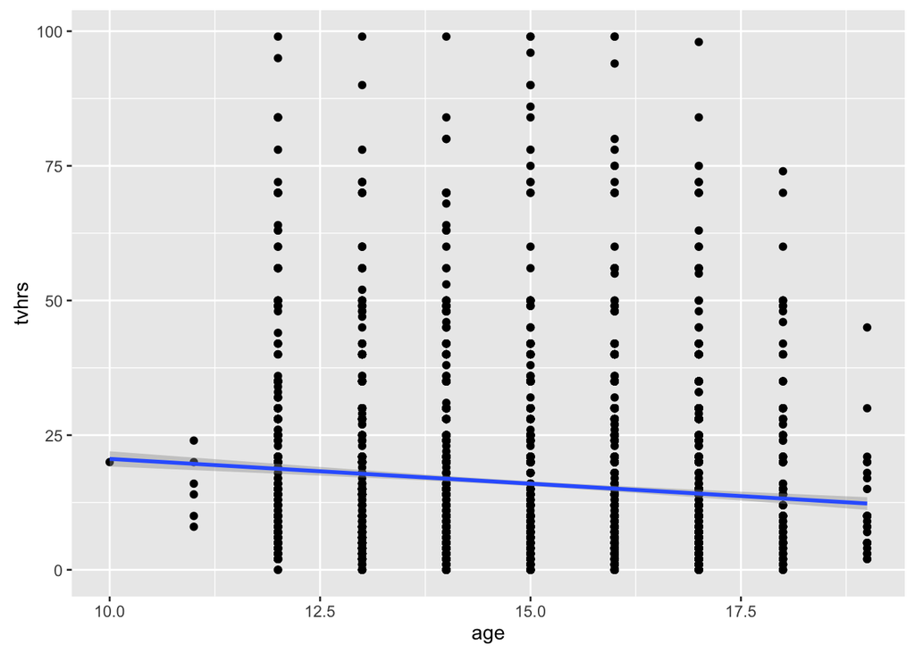

```r
ggplot(addhealth, aes(age, tvhrs)) + geom_point() + stat_smooth(method="lm")
```

Overall, how would you describe the relationship between age and tvhours based on this graph?

We can also look at the plots for different race/ethnicity groups How would you describe those relationships?

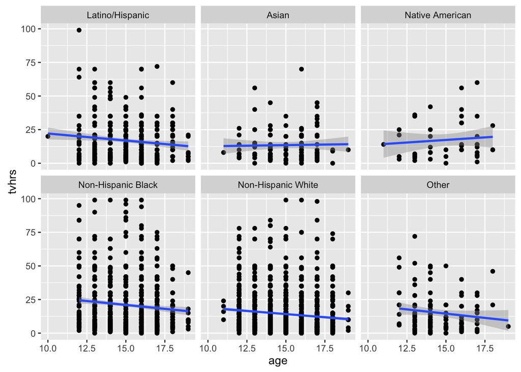

```r
ggplot(addhealth, aes(age, tvhrs)) + geom_point() +
    stat_smooth(method="lm")+
    facet_wrap(~raceeth)
```

We can also describe the plot numerically using a regression equation.

```r
reg1 <- lm(tvhrs~age)
coef(summary(reg1))
```

```
##              Estimate Std. Error   t value     Pr(>|t|)
## (Intercept) 29.802188  2.0696925 14.399332 7.164089e-46
## age         -0.920671  0.1374226 -6.699561 2.381335e-11
```

What sign is the estimate for age? The estimate is a slope. Does the sign indicate that hours spent watching television increase or decrease as children get older?

Does the direction of the Estimate match the direction shown in the graph?

Now let’s do separate regressions by race/ethnicity. This is a little complicated by the code says to use the addhealth data, broken down by the raceeth variable using the tbhrs ~age model

```r
regbygroup <- addhealth %>% group_by(raceeth) %>% do(model = lm(tvhrs ~ age,
    data = .))
options(dplyr.width = Inf)
results = tidy(regbygroup, model)

results
```

Source: local data frame [12 x 6] Groups: raceeth [6]

[output not shown]

How do the coefficients for age by race/ethnicity relate to the graphs?

Summarize what the data show about the relationship of age and hours spent watching television by race and ethnicity.